# Statistical Inference Project 1

Eric VACHON

May 2015

### Overview

In this paper we explain and compare the distribution of 1000 simulations of the mean of 40 exponential distributions and the Central Limit Theorm (CLT).

First we compare Sample Mean Versus Theorical Mean, then the Sample Variance Versus Theorical Variance and at end the difference between our simulation and the CLT.

### Requirement and reproductibility

Library : ggplot2

```r
library(ggplot2)
```

If need install it : install.packages(“ggplot2”)

For reproducability, we fixe the seed :

```r
set.seed(19)
```

### Constants of the simulation

```r
lambda <- 0.2
n <- 40
nbSimul <- 1000
```

### Theoricals values

Mean of exponencial distribution = $\frac{1}{\lambda}$  
Standard deviation of the mean of n exponencial distribution = $\frac{1}{\lambda}*\frac{1}{\sqrt{n}}$  
The variance of the mean of n exponencial distribution = $(\frac{1}{\lambda}*\frac{1}{\sqrt{n}})^2$

```r
theoricalMean <- (1 / lambda)
theoricalStandardDeviation <- (1 / lambda)*(1/sqrt(n))
theoricalVariance <- ((1 / lambda)*(1/sqrt(n)))^2
```

Results :  
- theoricalMean = 5  
- theoricalStandardDeviation = 0.7905694  
- theoricalVariance = 0.625

### The data frame of the simulation

Here we are going to make a data frames with the result of nbSimul=1000 means of n=40 exponencial distribution

```r
mySimul <- data.frame()
for  (i in 1 : nbSimul)
{  mySimul <-  rbind(mySimul,c(i,mean(rexp(n, lambda))))}
names(mySimul) <- c('numSimul','valueSimul')
```

### 1. Sample Mean Versus Theorical Mean

Now we make the histogram of this 1000 simulations and put a line of the theorical mean

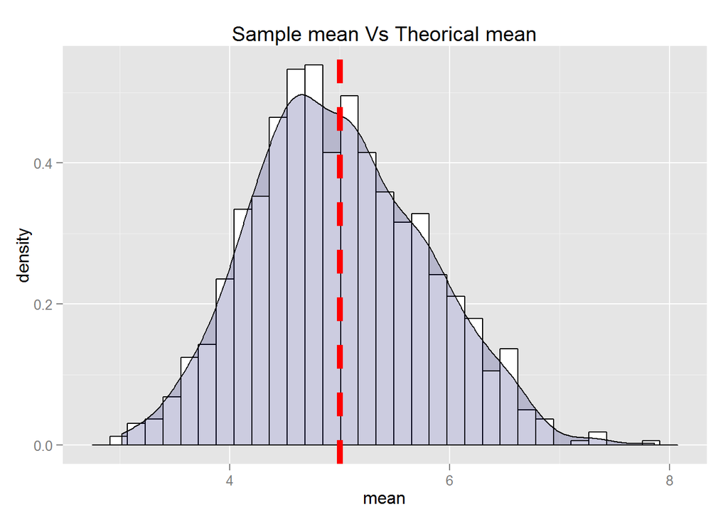

```r
ggplot(mySimul, aes(x=valueSimul))+
   geom_histogram(aes(y=..density..), colour="black", fill="white")+
   geom_density(alpha=.2, fill="#000066")+
   geom_vline(xintercept=theoricalMean,color="red",linetype="dashed",size=2)+
   ggtitle("Sample mean Vs Theorical mean")+labs(x = "mean")
```

And we can compare sample mean divide by theorical mean

```r
sampleMean <- mean(mySimul$valueSimul)
```

Results :  
- sampleMean = 4.9913111  
- theoricalMean = 5  
$\Rightarrow$ 0.17% of difference, so it is a good estimator.

### 2. Sample Variance Versus Theorical Variance

Here we must compare the therical variuance and the variance of our simulation :

```r
simulationVariance <- var(mySimul$valueSimul)
```

Results :  
- simulationVariance = 0.6172176  
- theoricalVariance = 0.625

$\Rightarrow$ 1.25% of difference, so it is a good estimator.

### 3. Distribution normal or not ?

To know if the distribution is approximately normal we draw a normal Quantile-Quantile plot :

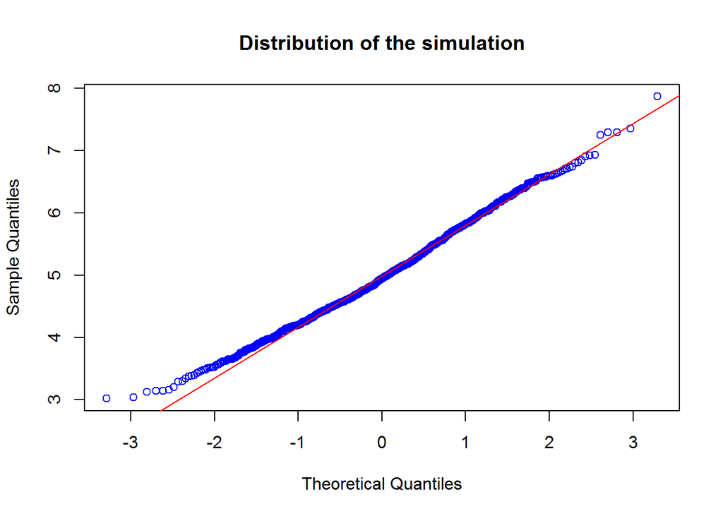

```r
qqnorm(mySimul$valueSim, col = 'blue',main = 'Distribution of the simulation')
qqline(mySimul$valueSim, col = 'red')
```

### Conclusion :

The theorical mean and variable are quite near the simulmation mean and variance and the blue circles follow the red line more or less at the extrems but follow it on the middle, so this distribution is approximately normal.